# R crash course

This is an R crash couse, adpated and revised based on an [online tutorial](https://billpetti.github.io/Crash_course_in_R/).

Let’s firstly setup a working directory

`r`r knitr::opts_knit$set(root.dir=/home/spr19/Desktop/PHC7065SPR2019/WK2)

We can assign objects using “<-”

`r`r foo <- world!  
foo

```
[1] \hello world!\
```

R is case-sensitive

`r`r myvar <- 1 Myvar

```
Error: object 'Myvar' not found
```

We can add comments by using “#”

`r`r #foo2 <- world!  
foo2

```
Error: object 'foo2' not found
```

Data structures:

Let’s look at vector first, which can be defined using c()

`r`r x <- c(1,2,3,4,5) x

```
[1] 1 2 3 4 5
```

`r`r firstNames <- c(,,,) firstNames

```
[1] \Shinji\ \Aska\   \Rey\    \Misato\
```

We can access the different parts of the vector using index: [idx]

`r`r firstNames[3]

```
[1] \Rey\
```

str() will allow us to explore the structure of a vector

`r`r str(firstNames)

```
 chr [1:4] \Shinji\ \Aska\ \Rey\ \Misato\
```

R treat categorical variables as factors. We can define that by using as.factor()

`r`r gender <- c(,,) gender <- as.factor(gender) str(gender)

```
 Factor w/ 2 levels \f\,\m\: 1 1 1 2 2 2
```

List is another data structure in R, which is a sequence of elements of different types

`r`r myList <- list(x=x,firstNames=firstNames,gender=gender) myList

```
$x
[1] 1 2 3 4 5

$firstNames
[1] \Shinji\ \Aska\   \Rey\    \Misato\

$gender
[1] f f f m m m
Levels: f m
```

We can access specific elements within the list

`r`r myList[[1]]

```
[1] 1 2 3 4 5
```

`r`r myList$x

```
[1] 1 2 3 4 5
```

`r`r myList[[]]

```
[1] 1 2 3 4 5
```

Now let’s move on to data frames

| franchise | city |
| --- | --- |
| Mets | New York |
| Nationals | Washington, DC |
| Marlins | Miami |
| Phillies | Philadelphia |
| Braves | Atlanta |

We can get names of variables using colnames()

`r`r colnames(teams)

```
[1] \franchise\ \city\
```

Let’s write our first function: mean calculation

`r`r our.mean <- function(x){ return(sum(x) / length(x)) }

Let’s run the function on some data

`r`r x <- c(1, 2, 3, 4, 5) x

```
[1] 1 2 3 4 5
```

`r`r our.mean(x) #self-defined mean

```
[1] 3
```

We can compare it with the built-in mean function

`r`r mean(x) #built-in mean

```
[1] 3
```

`r`r mean(x) == our.mean(x) #check whether these two values are equivalent

```
[1] TRUE
```

A more complex function

`r`r our.summary <- function(x) { mean <- mean(x) median <- median(x) standard_deviation <- sd(x) foo <- cbind(mean, median, standard_deviation) return(foo) } our.summary(x)

```
     mean median standard_deviation
[1,]    3      3           1.581139
```

Install, load, and unload packages

`r`r install.packages(2) #install

```
Error in install.packages : Updating loaded packages
```

`r`r library(ggplot2) #load detach(:ggplot2) #unload

Read data into R

`r`r dat1 <- read.csv(1.csv,header = TRUE, na.strings=) str(dat1)

```
'data.frame':   13988 obs. of  13 variables:
 $ Season  : int  2000 1999 2015 2000 1998 1999 2014 2002 2008 2009 ...
 $ Name    : Factor w/ 7571 levels \A.J. Burnett\,..: 1 1 2 3 3 3 4 5 6 6 ...
 $ Team    : Factor w/ 119 levels \- - -\,\Alleghenys\,..: 61 61 71 110 110 110 80 95 7 7 ...
 $ G       : int  13 7 3 33 7 9 2 9 22 23 ...
 $ PA      : int  30 17 2 96 13 24 5 12 87 57 ...
 $ wOBA    : num  0.375 0.106 0 0.353 0.319 0.316 0 0.081 0.309 0.208 ...
 $ wRCplus : int  122 -50 -100 103 85 79 -100 -83 88 19 ...
 $ BsR     : num  0 0 0 0.2 0 0 0 0 0.2 -0.1 ...
 $ Off     : num  0.9 -3.5 -0.5 0.6 -0.3 -0.7 -1.2 -2.7 -1.1 -5.9 ...
 $ Def     : num  3.5 1.9 0.2 2 -0.7 0.4 0.1 1.2 0.5 -1.8 ...
 $ WAR     : num  0.5 -0.1 0 0.6 -0.1 0.1 -0.1 -0.1 0.2 -0.6 ...
 $ Age     : int  23 22 23 23 21 22 23 23 22 23 ...
 $ playerid: int  512 512 11467 746 746 746 11270 1571 4087 4087 ...
```

`r`r head(dat1)

|  | Season | Name | Team | G | PA | wOBA | wRCplus | BsR | Off | Def | WAR | Age | playerid |
| --- | --- | --- | --- | --- | --- | --- | --- | --- | --- | --- | --- | --- | --- |
| 1 | 2000 | A.J. Burnett | Marlins | 13 | 30 | 0.375 | 122 | 0.0 | 0.9 | 3.5 | 0.5 | 23 | 512 |
| 2 | 1999 | A.J. Burnett | Marlins | 7 | 17 | 0.106 | -50 | 0.0 | -3.5 | 1.9 | -0.1 | 22 | 512 |
| 3 | 2015 | A.J. Cole | Nationals | 3 | 2 | 0.000 | -100 | 0.0 | -0.5 | 0.2 | 0.0 | 23 | 11467 |
| 4 | 2000 | A.J. Pierzynski | Twins | 33 | 96 | 0.353 | 103 | 0.2 | 0.6 | 2.0 | 0.6 | 23 | 746 |
| 5 | 1998 | A.J. Pierzynski | Twins | 7 | 13 | 0.319 | 85 | 0.0 | -0.3 | -0.7 | -0.1 | 21 | 746 |
| 6 | 1999 | A.J. Pierzynski | Twins | 9 | 24 | 0.316 | 79 | 0.0 | -0.7 | 0.4 | 0.1 | 22 | 746 |

Treat strings as non-factors

`r`r dat1 <- read.csv(1.csv,header = TRUE, na.strings=,stringsAsFactors = FALSE) str(dat1)

```
'data.frame':   13988 obs. of  13 variables:
 $ Season  : int  2000 1999 2015 2000 1998 1999 2014 2002 2008 2009 ...
 $ Name    : chr  \A.J. Burnett\ \A.J. Burnett\ \A.J. Cole\ \A.J. Pierzynski\ ...
 $ Team    : chr  \Marlins\ \Marlins\ \Nationals\ \Twins\ ...
 $ G       : int  13 7 3 33 7 9 2 9 22 23 ...
 $ PA      : int  30 17 2 96 13 24 5 12 87 57 ...
 $ wOBA    : num  0.375 0.106 0 0.353 0.319 0.316 0 0.081 0.309 0.208 ...
 $ wRCplus : int  122 -50 -100 103 85 79 -100 -83 88 19 ...
 $ BsR     : num  0 0 0 0.2 0 0 0 0 0.2 -0.1 ...
 $ Off     : num  0.9 -3.5 -0.5 0.6 -0.3 -0.7 -1.2 -2.7 -1.1 -5.9 ...
 $ Def     : num  3.5 1.9 0.2 2 -0.7 0.4 0.1 1.2 0.5 -1.8 ...
 $ WAR     : num  0.5 -0.1 0 0.6 -0.1 0.1 -0.1 -0.1 0.2 -0.6 ...
 $ Age     : int  23 22 23 23 21 22 23 23 22 23 ...
 $ playerid: int  512 512 11467 746 746 746 11270 1571 4087 4087 ...
```

`r`r head(dat1)

|  | Season | Name | Team | G | PA | wOBA | wRCplus | BsR | Off | Def | WAR | Age | playerid |
| --- | --- | --- | --- | --- | --- | --- | --- | --- | --- | --- | --- | --- | --- |
| 1 | 2000 | A.J. Burnett | Marlins | 13 | 30 | 0.375 | 122 | 0.0 | 0.9 | 3.5 | 0.5 | 23 | 512 |
| 2 | 1999 | A.J. Burnett | Marlins | 7 | 17 | 0.106 | -50 | 0.0 | -3.5 | 1.9 | -0.1 | 22 | 512 |
| 3 | 2015 | A.J. Cole | Nationals | 3 | 2 | 0.000 | -100 | 0.0 | -0.5 | 0.2 | 0.0 | 23 | 11467 |
| 4 | 2000 | A.J. Pierzynski | Twins | 33 | 96 | 0.353 | 103 | 0.2 | 0.6 | 2.0 | 0.6 | 23 | 746 |
| 5 | 1998 | A.J. Pierzynski | Twins | 7 | 13 | 0.319 | 85 | 0.0 | -0.3 | -0.7 | -0.1 | 21 | 746 |
| 6 | 1999 | A.J. Pierzynski | Twins | 9 | 24 | 0.316 | 79 | 0.0 | -0.7 | 0.4 | 0.1 | 22 | 746 |

We can output data from R

`r`r write.csv(dat1,~/Desktop/dat2.csv,row.names = F)

Some data manipulation using the built-in data “iris”

`r`r data(iris) #load the built-in data  
head(iris) r head(iris$Sepal.Length)

```
[1] 5.1 4.9 4.7 4.6 5.0 5.4
```

[output not shown]

An easier way to access more than one variables

`r`r head(with(iris,Sepal.Length/Sepal.Width))

```
[1] 1.457143 1.633333 1.468750 1.483871 1.388889 1.384615
```

`r`r iris$sepal_length_width_ratio <- with(iris, Sepal.Length / Sepal.Width) head(iris) ``` ```r iris$sepal_length_width_ratio <- round(iris$sepal_length_width_ratio, 2) head(iris)

|  | Sepal.Length | Sepal.Width | Petal.Length | Petal.Width | Species | sepal_length_width_ratio |
| --- | --- | --- | --- | --- | --- | --- |
| 1 | 5.1 | 3.5 | 1.4 | 0.2 | setosa | 1.457143 |
| 2 | 4.9 | 3.0 | 1.4 | 0.2 | setosa | 1.633333 |
| 3 | 4.7 | 3.2 | 1.3 | 0.2 | setosa | 1.468750 |
| 4 | 4.6 | 3.1 | 1.5 | 0.2 | setosa | 1.483871 |
| 5 | 5.0 | 3.6 | 1.4 | 0.2 | setosa | 1.388889 |
| 6 | 5.4 | 3.9 | 1.7 | 0.4 | setosa | 1.384615 |

|  | Sepal.Length | Sepal.Width | Petal.Length | Petal.Width | Species | sepal_length_width_ratio |
| --- | --- | --- | --- | --- | --- | --- |
| 1 | 5.1 | 3.5 | 1.4 | 0.2 | setosa | 1.46 |
| 2 | 4.9 | 3.0 | 1.4 | 0.2 | setosa | 1.63 |
| 3 | 4.7 | 3.2 | 1.3 | 0.2 | setosa | 1.47 |
| 4 | 4.6 | 3.1 | 1.5 | 0.2 | setosa | 1.48 |
| 5 | 5.0 | 3.6 | 1.4 | 0.2 | setosa | 1.39 |
| 6 | 5.4 | 3.9 | 1.7 | 0.4 | setosa | 1.38 |

Categorize a variable into tertiles

`r`r iris$sepal_length_width_ratioG<-cut(iris$sepal_length_width_ratio,breaks=quantile(iris$sepal_length_width_ratio,probs=c(0,0.33,0.67,1)),include.lowest = T) str(iris)

[output not shown]

Convert factor into numeric

`r`r iris$sepal_length_width_ratioG<-as.numeric(iris$sepal_length_width_ratioG) str(iris)

```
'data.frame':   150 obs. of  7 variables:
 $ Sepal.Length             : num  5.1 4.9 4.7 4.6 5 5.4 4.6 5 4.4 4.9 ...
 $ Sepal.Width              : num  3.5 3 3.2 3.1 3.6 3.9 3.4 3.4 2.9 3.1 ...
 $ Petal.Length             : num  1.4 1.4 1.3 1.5 1.4 1.7 1.4 1.5 1.4 1.5 ...
 $ Petal.Width              : num  0.2 0.2 0.2 0.2 0.2 0.4 0.3 0.2 0.2 0.1 ...
 $ Species                  : Factor w/ 3 levels \setosa\,\versicolor\,..: 1 1 1 1 1 1 1 1 1 1 ...
 $ sepal_length_width_ratio : num  1.46 1.63 1.47 1.48 1.39 1.38 1.35 1.47 1.52 1.58 ...
 $ sepal_length_width_ratioG: num  1 1 1 1 1 1 1 1 1 1 ...
```

Quick summary of a variable

`r`r summary(iris$sepal_length_width_ratio)

```
   Min. 1st Qu.  Median    Mean 3rd Qu.    Max.
  1.270   1.550   2.030   1.954   2.228   2.960
```

Subsetting data

`r`r unique(iris$Species)

```
[1] setosa     versicolor virginica
Levels: setosa versicolor virginica
```

`r`r sub_virginica <- subset(iris, Species == ) head(sub_virginica) r unique(sub_virginica$Species)

```
[1] virginica
Levels: setosa versicolor virginica
```

`r`r ex_virginica <- subset(iris, Species != ) unique(ex_virginica$Species)

```
[1] setosa     versicolor
Levels: setosa versicolor virginica
```

`r`r sub_virginica2 <- subset(iris, Species != & sepal_length_width_ratio >= 2) head(sub_virginica2)

[output not shown]

|  | Sepal.Length | Sepal.Width | Petal.Length | Petal.Width | Species | sepal_length_width_ratio | sepal_length_width_ratioG |
| --- | --- | --- | --- | --- | --- | --- | --- |
| 51 | 7.0 | 3.2 | 4.7 | 1.4 | versicolor | 2.19 | 3 |
| 52 | 6.4 | 3.2 | 4.5 | 1.5 | versicolor | 2.00 | 2 |
| 53 | 6.9 | 3.1 | 4.9 | 1.5 | versicolor | 2.23 | 3 |
| 54 | 5.5 | 2.3 | 4.0 | 1.3 | versicolor | 2.39 | 3 |
| 55 | 6.5 | 2.8 | 4.6 | 1.5 | versicolor | 2.32 | 3 |
| 56 | 5.7 | 2.8 | 4.5 | 1.3 | versicolor | 2.04 | 2 |

Select specific variables

`r`r head(iris[,c(1,3)])

|  | Sepal.Length | Petal.Length |
| --- | --- | --- |
| 1 | 5.1 | 1.4 |
| 2 | 4.9 | 1.4 |
| 3 | 4.7 | 1.3 |
| 4 | 4.6 | 1.5 |
| 5 | 5.0 | 1.4 |
| 6 | 5.4 | 1.7 |

Select specific cases/rows

`r`r iris[c(1:6),]

|  | Sepal.Length | Sepal.Width | Petal.Length | Petal.Width | Species | sepal_length_width_ratio | sepal_length_width_ratioG |
| --- | --- | --- | --- | --- | --- | --- | --- |
| 1 | 5.1 | 3.5 | 1.4 | 0.2 | setosa | 1.46 | 1 |
| 2 | 4.9 | 3.0 | 1.4 | 0.2 | setosa | 1.63 | 1 |
| 3 | 4.7 | 3.2 | 1.3 | 0.2 | setosa | 1.47 | 1 |
| 4 | 4.6 | 3.1 | 1.5 | 0.2 | setosa | 1.48 | 1 |
| 5 | 5.0 | 3.6 | 1.4 | 0.2 | setosa | 1.39 | 1 |
| 6 | 5.4 | 3.9 | 1.7 | 0.4 | setosa | 1.38 | 1 |

Basic descriptive and summary statistics

`r`r data(airquality) summary(airquality)

```
     Ozone           Solar.R           Wind             Temp           Month
 Min.   :  1.00   Min.   :  7.0   Min.   : 1.700   Min.   :56.00   Min.   :5.000
 1st Qu.: 18.00   1st Qu.:115.8   1st Qu.: 7.400   1st Qu.:72.00   1st Qu.:6.000
 Median : 31.50   Median :205.0   Median : 9.700   Median :79.00   Median :7.000
 Mean   : 42.13   Mean   :185.9   Mean   : 9.958   Mean   :77.88   Mean   :6.993
 3rd Qu.: 63.25   3rd Qu.:258.8   3rd Qu.:11.500   3rd Qu.:85.00   3rd Qu.:8.000
 Max.   :168.00   Max.   :334.0   Max.   :20.700   Max.   :97.00   Max.   :9.000
 NA's   :37       NA's   :7
      Day
 Min.   : 1.0
 1st Qu.: 8.0
 Median :16.0
 Mean   :15.8
 3rd Qu.:23.0
 Max.   :31.0
```

dplyr package

`r`r if (!require(dplyr)) { install.packages(dplyr) }

Frequency tables

`r`r with(iris,table(Species,Petal.Width))

```
            Petal.Width
Species      0.1 0.2 0.3 0.4 0.5 0.6  1 1.1 1.2 1.3 1.4 1.5 1.6 1.7 1.8 1.9  2 2.1
  setosa       5  29   7   7   1   1  0   0   0   0   0   0   0   0   0   0  0   0
  versicolor   0   0   0   0   0   0  7   3   5  13   7  10   3   1   1   0  0   0
  virginica    0   0   0   0   0   0  0   0   0   0   1   2   1   1  11   5  6   6
            Petal.Width
Species      2.2 2.3 2.4 2.5
  setosa       0   0   0   0
  versicolor   0   0   0   0
  virginica    3   8   3   3
```

`r`r table(iris$Species,iris$Petal.Width)

```
             0.1 0.2 0.3 0.4 0.5 0.6  1 1.1 1.2 1.3 1.4 1.5 1.6 1.7 1.8 1.9  2 2.1
  setosa       5  29   7   7   1   1  0   0   0   0   0   0   0   0   0   0  0   0
  versicolor   0   0   0   0   0   0  7   3   5  13   7  10   3   1   1   0  0   0
  virginica    0   0   0   0   0   0  0   0   0   0   1   2   1   1  11   5  6   6

             2.2 2.3 2.4 2.5
  setosa       0   0   0   0
  versicolor   0   0   0   0
  virginica    3   8   3   3
```

`r`r with(iris, table(Species, Petal.Width)) %>% prop.table()

```
            Petal.Width
Species              0.1         0.2         0.3         0.4         0.5
  setosa     0.033333333 0.193333333 0.046666667 0.046666667 0.006666667
  versicolor 0.000000000 0.000000000 0.000000000 0.000000000 0.000000000
  virginica  0.000000000 0.000000000 0.000000000 0.000000000 0.000000000
            Petal.Width
Species              0.6           1         1.1         1.2         1.3
  setosa     0.006666667 0.000000000 0.000000000 0.000000000 0.000000000
  versicolor 0.000000000 0.046666667 0.020000000 0.033333333 0.086666667
  virginica  0.000000000 0.000000000 0.000000000 0.000000000 0.000000000
            Petal.Width
Species              1.4         1.5         1.6         1.7         1.8
  setosa     0.000000000 0.000000000 0.000000000 0.000000000 0.000000000
  versicolor 0.046666667 0.066666667 0.020000000 0.006666667 0.006666667
  virginica  0.006666667 0.013333333 0.006666667 0.006666667 0.073333333
            Petal.Width
Species              1.9           2         2.1         2.2         2.3
  setosa     0.000000000 0.000000000 0.000000000 0.000000000 0.000000000
  versicolor 0.000000000 0.000000000 0.000000000 0.000000000 0.000000000
  virginica  0.033333333 0.040000000 0.040000000 0.020000000 0.053333333
            Petal.Width
Species              2.4         2.5
  setosa     0.000000000 0.000000000
  versicolor 0.000000000 0.000000000
  virginica  0.020000000 0.020000000
```

`r`r with(iris, table(Species, Petal.Width)) %>% prop.table(margin = 1) #row frequencies

```
            Petal.Width
Species       0.1  0.2  0.3  0.4  0.5  0.6    1  1.1  1.2  1.3  1.4  1.5  1.6  1.7
  setosa     0.10 0.58 0.14 0.14 0.02 0.02 0.00 0.00 0.00 0.00 0.00 0.00 0.00 0.00
  versicolor 0.00 0.00 0.00 0.00 0.00 0.00 0.14 0.06 0.10 0.26 0.14 0.20 0.06 0.02
  virginica  0.00 0.00 0.00 0.00 0.00 0.00 0.00 0.00 0.00 0.00 0.02 0.04 0.02 0.02
            Petal.Width
Species       1.8  1.9    2  2.1  2.2  2.3  2.4  2.5
  setosa     0.00 0.00 0.00 0.00 0.00 0.00 0.00 0.00
  versicolor 0.02 0.00 0.00 0.00 0.00 0.00 0.00 0.00
  virginica  0.22 0.10 0.12 0.12 0.06 0.16 0.06 0.06
```

`r`r with(iris, table(Species, Petal.Width)) %>% prop.table(margin = 2) #column frequencies

```
            Petal.Width
Species             0.1        0.2        0.3        0.4        0.5        0.6
  setosa     1.00000000 1.00000000 1.00000000 1.00000000 1.00000000 1.00000000
  versicolor 0.00000000 0.00000000 0.00000000 0.00000000 0.00000000 0.00000000
  virginica  0.00000000 0.00000000 0.00000000 0.00000000 0.00000000 0.00000000
            Petal.Width
Species               1        1.1        1.2        1.3        1.4        1.5
  setosa     0.00000000 0.00000000 0.00000000 0.00000000 0.00000000 0.00000000
  versicolor 1.00000000 1.00000000 1.00000000 1.00000000 0.87500000 0.83333333
  virginica  0.00000000 0.00000000 0.00000000 0.00000000 0.12500000 0.16666667
            Petal.Width
Species             1.6        1.7        1.8        1.9          2        2.1
  setosa     0.00000000 0.00000000 0.00000000 0.00000000 0.00000000 0.00000000
  versicolor 0.75000000 0.50000000 0.08333333 0.00000000 0.00000000 0.00000000
  virginica  0.25000000 0.50000000 0.91666667 1.00000000 1.00000000 1.00000000
            Petal.Width
Species             2.2        2.3        2.4        2.5
  setosa     0.00000000 0.00000000 0.00000000 0.00000000
  versicolor 0.00000000 0.00000000 0.00000000 0.00000000
  virginica  1.00000000 1.00000000 1.00000000 1.00000000
```

`r`r cross_column<-with(iris, table(Species, Petal.Width)) %>% prop.table(margin = 2) %>% as.data.frame.matrix()

Basic statistics and modeling

`r`r dat2<-read.csv(_sample_data.csv,header = T, stringsAsFactors = F) str(dat2)

```
'data.frame':   116 obs. of  19 variables:
 $ resp: int  1 2 3 4 5 6 7 8 9 10 ...
 $ Q1  : int  NA 4 4 4 4 4 4 4 3 2 ...
 $ Q2  : int  4 4 4 3 2 4 4 4 4 4 ...
 $ Q3  : int  4 4 4 4 3 5 4 4 4 5 ...
 $ Q4  : int  2 4 2 3 3 5 3 3 4 5 ...
 $ Q5  : int  4 4 4 3 2 4 4 4 4 4 ...
 $ Q6  : int  3 4 4 4 4 4 3 4 4 4 ...
 $ Q7  : int  3 5 4 4 3 5 4 4 4 4 ...
 $ Q8  : int  4 5 4 4 2 4 4 4 4 2 ...
 $ Q9  : int  4 5 4 3 4 5 4 4 4 4 ...
 $ Q10 : int  4 5 3 3 4 5 4 3 3 4 ...
 $ Q11 : int  4 5 3 4 4 5 4 3 4 5 ...
 $ Q12 : int  4 5 3 3 3 5 4 3 4 5 ...
 $ Q13 : int  2 5 4 NA 4 4 4 4 4 4 ...
 $ Q14 : int  3 4 4 NA 3 4 4 4 4 5 ...
 $ Q15 : int  2 5 4 NA 3 5 4 4 4 4 ...
 $ Q16 : int  3 5 4 NA 3 4 4 4 4 4 ...
 $ Q17 : int  2 5 4 NA 3 5 4 4 4 4 ...
 $ Q18 : int  2 4 4 NA 3 4 4 4 4 4 ...
```

Correlation

`r`r cor(dat2$Q1,dat2$Q2,use=.complete.obs)

```
[1] 0.3530547
```

`r`r cor(dat2[,c(2:19)], use = .complete.obs)

```
           Q1        Q2        Q3        Q4        Q5        Q6        Q7
Q1  1.0000000 0.3530547 0.2795366 0.3622114 0.5084621 0.5020899 0.3890393
Q2  0.3530547 1.0000000 0.4929452 0.4018380 0.6867940 0.4315408 0.4099012
Q3  0.2795366 0.4929452 1.0000000 0.3734676 0.4808017 0.3082121 0.4296335
Q4  0.3622114 0.4018380 0.3734676 1.0000000 0.5002671 0.5327641 0.4916112
Q5  0.5084621 0.6867940 0.4808017 0.5002671 1.0000000 0.6151182 0.3919843
Q6  0.5020899 0.4315408 0.3082121 0.5327641 0.6151182 1.0000000 0.2483472
Q7  0.3890393 0.4099012 0.4296335 0.4916112 0.3919843 0.2483472 1.0000000
Q8  0.5546423 0.4953152 0.2911457 0.4896858 0.6624960 0.4594599 0.4462642
Q9  0.2447631 0.3743698 0.2412326 0.3774773 0.3723951 0.2713626 0.3602243
Q10 0.2943226 0.3503423 0.2962857 0.2459652 0.2829191 0.1494707 0.2797152
Q11 0.4025170 0.4994398 0.5821536 0.4807319 0.5199376 0.3700152 0.4602307
Q12 0.4346825 0.4942049 0.3431898 0.4840651 0.5926707 0.4260840 0.3559327
Q13 0.2770672 0.4307978 0.3053565 0.3114811 0.4616674 0.4434746 0.1689025
Q14 0.4546998 0.5478055 0.4221599 0.5087520 0.6610591 0.4503442 0.3615443
Q15 0.4513441 0.4881214 0.3913010 0.4363918 0.5953248 0.5134326 0.3494344
Q16 0.2497878 0.3998728 0.3343669 0.2937605 0.5200958 0.3468950 0.3103625
Q17 0.5075967 0.4585881 0.3230303 0.4518362 0.5605630 0.6095168 0.3917240
Q18 0.5336075 0.5868238 0.4167338 0.4743020 0.7434688 0.5561488 0.4894299
           Q8        Q9       Q10       Q11       Q12       Q13       Q14
Q1  0.5546423 0.2447631 0.2943226 0.4025170 0.4346825 0.2770672 0.4546998
Q2  0.4953152 0.3743698 0.3503423 0.4994398 0.4942049 0.4307978 0.5478055
Q3  0.2911457 0.2412326 0.2962857 0.5821536 0.3431898 0.3053565 0.4221599
Q4  0.4896858 0.3774773 0.2459652 0.4807319 0.4840651 0.3114811 0.5087520
Q5  0.6624960 0.3723951 0.2829191 0.5199376 0.5926707 0.4616674 0.6610591
Q6  0.4594599 0.2713626 0.1494707 0.3700152 0.4260840 0.4434746 0.4503442
Q7  0.4462642 0.3602243 0.2797152 0.4602307 0.3559327 0.1689025 0.3615443
Q8  1.0000000 0.4472036 0.2732867 0.4153304 0.5801349 0.4240773 0.6031554
Q9  0.4472036 1.0000000 0.3505359 0.3477078 0.4194848 0.5645268 0.4104143
Q10 0.2732867 0.3505359 1.0000000 0.4985688 0.5801269 0.2757172 0.4224534
Q11 0.4153304 0.3477078 0.4985688 1.0000000 0.6071194 0.3669644 0.5099021
Q12 0.5801349 0.4194848 0.5801269 0.6071194 1.0000000 0.3134537 0.6388020
Q13 0.4240773 0.5645268 0.2757172 0.3669644 0.3134537 1.0000000 0.4566671
Q14 0.6031554 0.4104143 0.4224534 0.5099021 0.6388020 0.4566671 1.0000000
Q15 0.5201491 0.4660026 0.4858433 0.4715965 0.5379101 0.6387456 0.6264466
Q16 0.3847740 0.2175714 0.3239532 0.4954887 0.4434703 0.2578720 0.5863867
Q17 0.6356982 0.5446046 0.4379516 0.4413625 0.5627799 0.6819639 0.6511217
Q18 0.6283656 0.3477020 0.3496391 0.5808842 0.5873540 0.5195240 0.7138305
          Q15       Q16       Q17       Q18
Q1  0.4513441 0.2497878 0.5075967 0.5336075
Q2  0.4881214 0.3998728 0.4585881 0.5868238
Q3  0.3913010 0.3343669 0.3230303 0.4167338
Q4  0.4363918 0.2937605 0.4518362 0.4743020
Q5  0.5953248 0.5200958 0.5605630 0.7434688
Q6  0.5134326 0.3468950 0.6095168 0.5561488
Q7  0.3494344 0.3103625 0.3917240 0.4894299
Q8  0.5201491 0.3847740 0.6356982 0.6283656
Q9  0.4660026 0.2175714 0.5446046 0.3477020
Q10 0.4858433 0.3239532 0.4379516 0.3496391
Q11 0.4715965 0.4954887 0.4413625 0.5808842
Q12 0.5379101 0.4434703 0.5627799 0.5873540
Q13 0.6387456 0.2578720 0.6819639 0.5195240
Q14 0.6264466 0.5863867 0.6511217 0.7138305
Q15 1.0000000 0.4271233 0.7606402 0.6382698
Q16 0.4271233 1.0000000 0.3944430 0.5608581
Q17 0.7606402 0.3944430 1.0000000 0.6956187
Q18 0.6382698 0.5608581 0.6956187 1.0000000
```

`r`r round(cor(dat2[,c(2:19)], use = .complete.obs),3)

```
       Q1    Q2    Q3    Q4    Q5    Q6    Q7    Q8    Q9   Q10   Q11   Q12   Q13
Q1  1.000 0.353 0.280 0.362 0.508 0.502 0.389 0.555 0.245 0.294 0.403 0.435 0.277
Q2  0.353 1.000 0.493 0.402 0.687 0.432 0.410 0.495 0.374 0.350 0.499 0.494 0.431
Q3  0.280 0.493 1.000 0.373 0.481 0.308 0.430 0.291 0.241 0.296 0.582 0.343 0.305
Q4  0.362 0.402 0.373 1.000 0.500 0.533 0.492 0.490 0.377 0.246 0.481 0.484 0.311
Q5  0.508 0.687 0.481 0.500 1.000 0.615 0.392 0.662 0.372 0.283 0.520 0.593 0.462
Q6  0.502 0.432 0.308 0.533 0.615 1.000 0.248 0.459 0.271 0.149 0.370 0.426 0.443
Q7  0.389 0.410 0.430 0.492 0.392 0.248 1.000 0.446 0.360 0.280 0.460 0.356 0.169
Q8  0.555 0.495 0.291 0.490 0.662 0.459 0.446 1.000 0.447 0.273 0.415 0.580 0.424
Q9  0.245 0.374 0.241 0.377 0.372 0.271 0.360 0.447 1.000 0.351 0.348 0.419 0.565
Q10 0.294 0.350 0.296 0.246 0.283 0.149 0.280 0.273 0.351 1.000 0.499 0.580 0.276
Q11 0.403 0.499 0.582 0.481 0.520 0.370 0.460 0.415 0.348 0.499 1.000 0.607 0.367
Q12 0.435 0.494 0.343 0.484 0.593 0.426 0.356 0.580 0.419 0.580 0.607 1.000 0.313
Q13 0.277 0.431 0.305 0.311 0.462 0.443 0.169 0.424 0.565 0.276 0.367 0.313 1.000
Q14 0.455 0.548 0.422 0.509 0.661 0.450 0.362 0.603 0.410 0.422 0.510 0.639 0.457
Q15 0.451 0.488 0.391 0.436 0.595 0.513 0.349 0.520 0.466 0.486 0.472 0.538 0.639
Q16 0.250 0.400 0.334 0.294 0.520 0.347 0.310 0.385 0.218 0.324 0.495 0.443 0.258
Q17 0.508 0.459 0.323 0.452 0.561 0.610 0.392 0.636 0.545 0.438 0.441 0.563 0.682
Q18 0.534 0.587 0.417 0.474 0.743 0.556 0.489 0.628 0.348 0.350 0.581 0.587 0.520
      Q14   Q15   Q16   Q17   Q18
Q1  0.455 0.451 0.250 0.508 0.534
Q2  0.548 0.488 0.400 0.459 0.587
Q3  0.422 0.391 0.334 0.323 0.417
Q4  0.509 0.436 0.294 0.452 0.474
Q5  0.661 0.595 0.520 0.561 0.743
Q6  0.450 0.513 0.347 0.610 0.556
Q7  0.362 0.349 0.310 0.392 0.489
Q8  0.603 0.520 0.385 0.636 0.628
Q9  0.410 0.466 0.218 0.545 0.348
Q10 0.422 0.486 0.324 0.438 0.350
Q11 0.510 0.472 0.495 0.441 0.581
Q12 0.639 0.538 0.443 0.563 0.587
Q13 0.457 0.639 0.258 0.682 0.520
Q14 1.000 0.626 0.586 0.651 0.714
Q15 0.626 1.000 0.427 0.761 0.638
Q16 0.586 0.427 1.000 0.394 0.561
Q17 0.651 0.761 0.394 1.000 0.696
Q18 0.714 0.638 0.561 0.696 1.000
```

Linear regression

`r`r head(iris) r iris_lm <-lm(Sepal.Length ~ Sepal.Width + Petal.Length + Petal.Width+ factor(Species),data=iris) summary(iris_lm)

```
Call:
lm(formula = Sepal.Length ~ Sepal.Width + Petal.Length + Petal.Width +
    factor(Species), data = iris)

Residuals:
     Min       1Q   Median       3Q      Max
-0.79424 -0.21874  0.00899  0.20255  0.73103

Coefficients:
                          Estimate Std. Error t value Pr(>|t|)
(Intercept)                2.17127    0.27979   7.760 1.43e-12 ***
Sepal.Width                0.49589    0.08607   5.761 4.87e-08 ***
Petal.Length               0.82924    0.06853  12.101  < 2e-16 ***
Petal.Width               -0.31516    0.15120  -2.084  0.03889 *
factor(Species)versicolor -0.72356    0.24017  -3.013  0.00306 **
factor(Species)virginica  -1.02350    0.33373  -3.067  0.00258 **
---
Signif. codes:  0 ‘***’ 0.001 ‘**’ 0.01 ‘*’ 0.05 ‘.’ 0.1 ‘ ’ 1

Residual standard error: 0.3068 on 144 degrees of freedom
Multiple R-squared:  0.8673,    Adjusted R-squared:  0.8627
F-statistic: 188.3 on 5 and 144 DF,  p-value: < 2.2e-16
```

`r`r iris_lm$coefficients

```
              (Intercept)               Sepal.Width              Petal.Length
                2.1712663                 0.4958889                 0.8292439
              Petal.Width factor(Species)versicolor  factor(Species)virginica
               -0.3151552                -0.7235620                -1.0234978
```

`r`r confint(iris_lm)

```
                               2.5 %      97.5 %
(Intercept)                1.6182321  2.72430044
Sepal.Width                0.3257653  0.66601260
Petal.Length               0.6937939  0.96469395
Petal.Width               -0.6140049 -0.01630542
factor(Species)versicolor -1.1982739 -0.24885002
factor(Species)virginica  -1.6831329 -0.36386273
```

[output not shown]

Visualization: Histogram

`r`r hist(dat2$Q2)

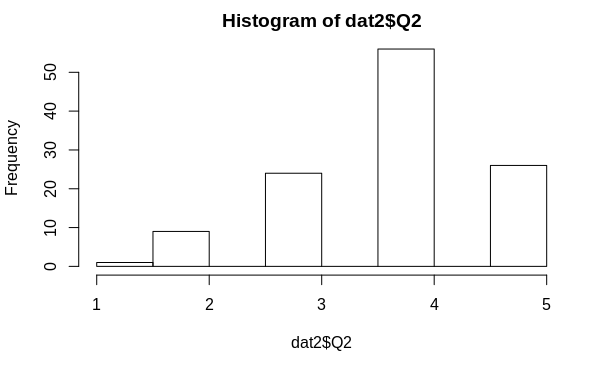

`r`r hist(dat2$Q2, main = of Responses to Q2, xlab = Value,breaks = c(0.0, 1.0, 2.0, 3.0, 4.0, 5.0))

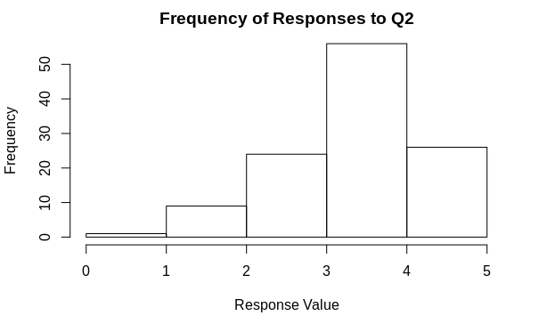

Scatterplots

`r`r plot(Sepal.Length~Sepal.Width,data=iris)

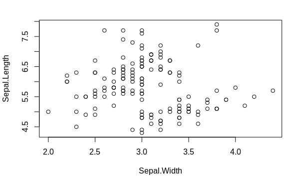

Boxplots

`r`r boxplot(iris$sepal_length_width_ratio)

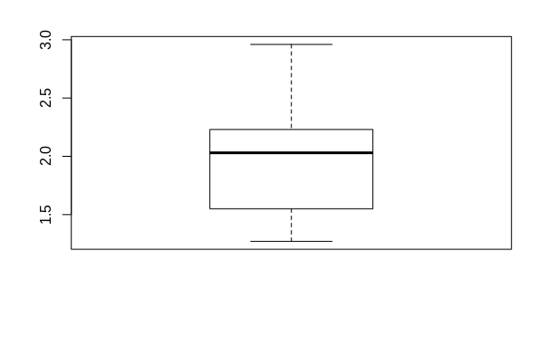

Use ggplot2 to enhance visualizations

`r`r if (!require(ggplot2)) { install.packages(ggplot2) }

Better scatterplots for iris

`r`r ggplot(iris,aes(x=Sepal.Width,y=Sepal.Length))+geom_point()

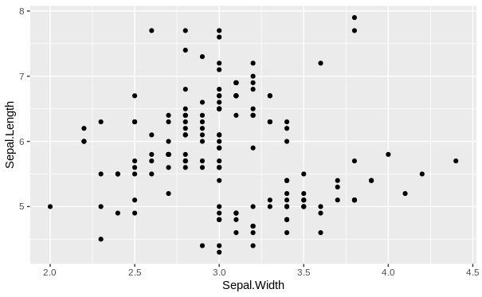

Different color by species

`r`r ggplot(iris,aes(x=Sepal.Width,y=Sepal.Length))+geom_point(aes(color=Species)) #

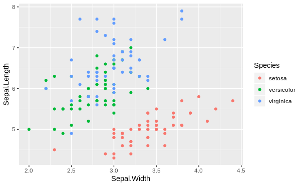

Differnet size proportional to sepal length width ratio

`r`r ggplot(iris,aes(x=Sepal.Width,y=Sepal.Length))+geom_point(aes(color=Species,size=sepal_length_width_ratio)) #

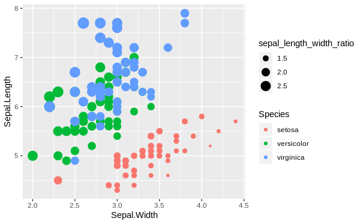

Add some transparency

`r`r ggplot(iris,aes(x=Sepal.Width,y=Sepal.Length))+geom_point(aes(color=Species,size=sepal_length_width_ratio,alpha=.3)) #

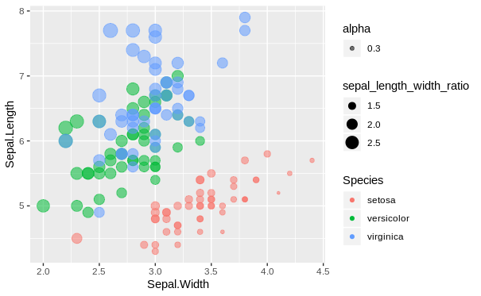

Add a trend line

`r`r ggplot(iris,aes(x=Sepal.Width,y=Sepal.Length))+geom_point(aes(color=Species,size=sepal_length_width_ratio,alpha=.3))+stat_smooth()

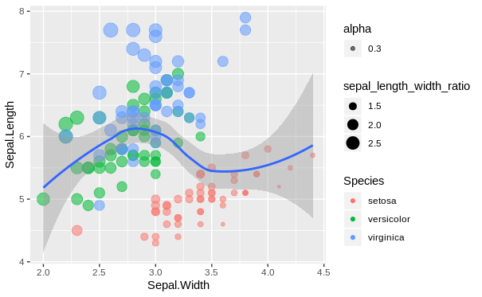

Seperate plots by species

`r`r ggplot(iris,aes(x=Sepal.Width,y=Sepal.Length))+geom_point(aes(color=Species,size=sepal_length_width_ratio,alpha=.3)) +stat_smooth() +facet_wrap(~Species) #separate plots by species

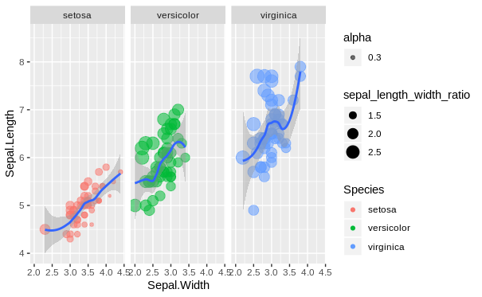

Density plots

`r`r if (!require(reshape2)) { install.packages(reshape2) }

`r`r dat2_melt<-melt(dat2[,c(2:19)])

`r`r ggplot(dat2_melt,aes(value))+geom_density()+facet_wrap(~variable) install.packages(2)

[output not shown]

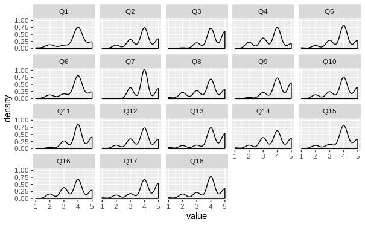

Boxplots

`r`r ggplot(iris,aes(y=sepal_length_width_ratio,x=Species))+geom_boxplot()

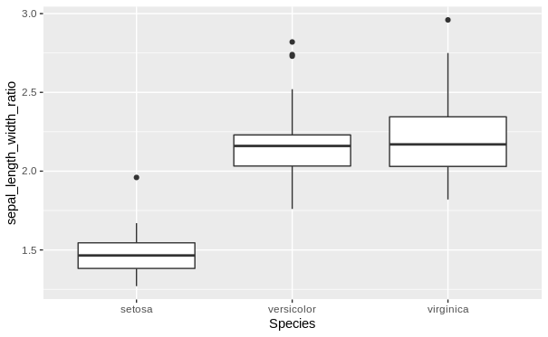

Customize

`r`r ggplot(iris,aes(x=Sepal.Width,y=Sepal.Length))+geom_point(aes(color=Species,size=sepal_length_width_ratio,alpha=.3)) +stat_smooth() +facet_wrap(~Species)

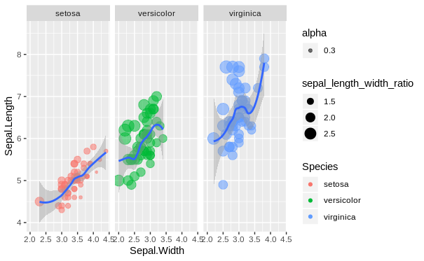

Add title

`r`r ggplot(iris,aes(x=Sepal.Width,y=Sepal.Length))+geom_point(aes(color=Species,size=sepal_length_width_ratio,alpha=.3)) +stat_smooth() +facet_wrap(~Species) + ggtitle(Length versus Sepal Width) + xlab(Width)+ylab(Length) #add title and labels

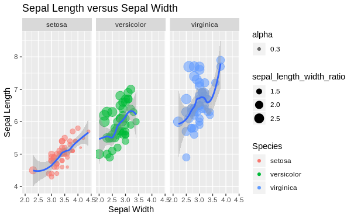

Resize and bold

`r`r ggplot(iris,aes(x=Sepal.Width,y=Sepal.Length))+geom_point(aes(color=Species,size=sepal_length_width_ratio,alpha=.3)) +stat_smooth() +facet_wrap(~Species) + ggtitle(Length versus Sepal Width) + xlab(Width)+ylab(Length) + theme(axis.title=element_text(face=,size=14),plot.title=element_text(face=,size=16)) #resize and bold

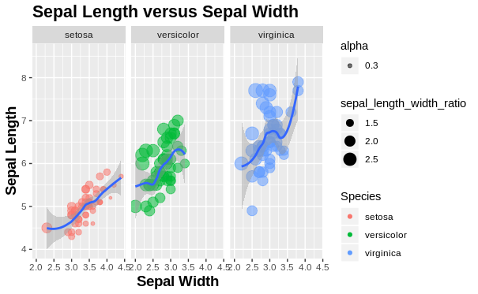

Remove the shading

`r`r ggplot(iris,aes(x=Sepal.Width,y=Sepal.Length))+geom_point(aes(color=Species,size=sepal_length_width_ratio,alpha=.3)) +stat_smooth() +facet_wrap(~Species) + ggtitle(Length versus Sepal Width) + xlab(Width)+ylab(Length) + theme(axis.title=element_text(face=,size=14),plot.title=element_text(face=,size=16))+ theme(panel.background=element_blank()) #remove the shading

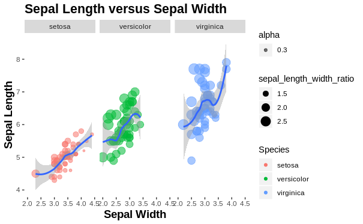

Use custom color palettes

`r`r ggplot(iris,aes(x=Sepal.Width,y=Sepal.Length))+geom_point(aes(color=Species,size=sepal_length_width_ratio,alpha=.3)) +stat_smooth() +facet_wrap(~Species) + ggtitle(Length versus Sepal Width) + xlab(Width)+ylab(Length) + theme(axis.title=element_text(face=,size=14),plot.title=element_text(face=,size=16))+ theme(panel.background=element_blank()) + scale_color_brewer(palette=) #use custom coclr palettes

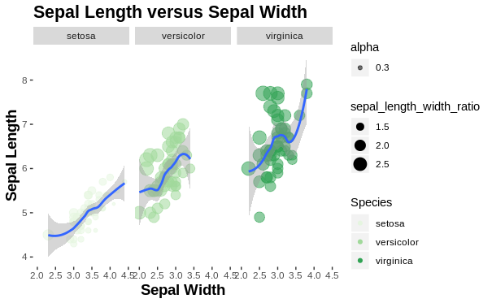

Correlation heatmap

`r`r dat2_cor_melt<-melt(cor(dat2[,c(2:19)],use=.complete.obs)) dat2_cor_melt$value<-round(dat2_cor_melt$value,2) head(dat2_cor_melt) r ggplot(dat2_cor_melt, aes(Var1, Var2)) + geom_tile(aes(fill = value)) + geom_text(aes(label=value), size = 3, fontface = ) + scale_fill_gradient2(low = #67a9cf, high = #ef8a62) +theme_minimal() +theme(panel.grid.major = element_blank(), panel.grid.minor = element_blank(), panel.border = element_blank(),panel.background = element_blank(), axis.title = element_blank(), axis.text = element_text(size = 12, face = ))

|  | Var1 | Var2 | value |
| --- | --- | --- | --- |
| 1 | Q1 | Q1 | 1.00 |
| 2 | Q2 | Q1 | 0.35 |
| 3 | Q3 | Q1 | 0.28 |
| 4 | Q4 | Q1 | 0.36 |
| 5 | Q5 | Q1 | 0.51 |
| 6 | Q6 | Q1 | 0.50 |

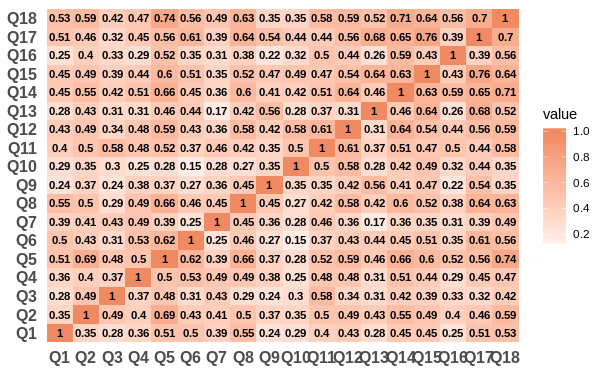

Remove 1s

`r`r dat2_cor_melt<-dat2_cor_melt[dat2_cor_melt$value!=1,] ggplot(dat2_cor_melt, aes(Var1, Var2)) + geom_tile(aes(fill = value)) + geom_text(aes(label=value), size = 3, fontface = ) + scale_fill_gradient2(low = #67a9cf, high = #ef8a62) +theme_minimal() +theme(panel.grid.major = element_blank(), panel.grid.minor = element_blank(), panel.border = element_blank(),panel.background = element_blank(), axis.title = element_blank(), axis.text = element_text(size = 12, face = ))

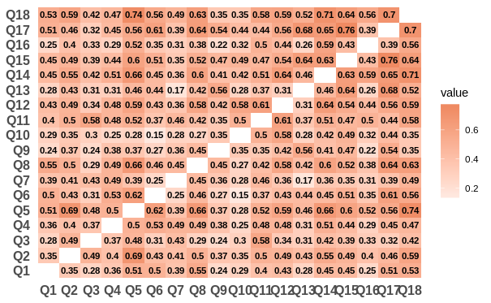

Remove labels

`r`r ggplot(dat2_cor_melt, aes(Var1, Var2)) + geom_tile(aes(fill = value)) + scale_fill_gradient2(low = #67a9cf, high = #ef8a62) +theme_minimal() +theme(panel.grid.major = element_blank(), panel.grid.minor = element_blank(), panel.border = element_blank(),panel.background = element_blank(), axis.title = element_blank(), axis.text = element_text(size = 12, face = ))

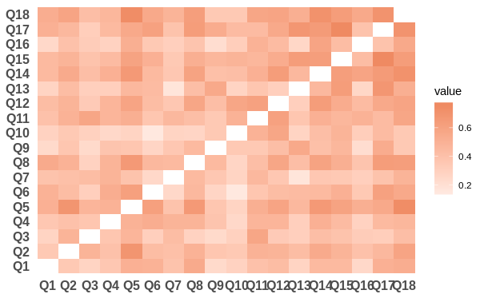